# Weight lifting problem

This document describes the steps followed to build a classifier to identify the manner in which a weight lifting exercise has been performed, based on data registered by four sets of sensors located in:

- Arm
- Forearm
- Belt
- Dumbbell

First, we import the data set

```r
train <- read.csv("pml-training.csv")
test <- read.csv("pml-testing.csv")
```

Then we check the dimensions of the data sets

```r
dim(train)
```

```
## [1] 19622   160
```

```r
names(train)
```

```
##   [1] "X"                        "user_name"
##   [3] "raw_timestamp_part_1"     "raw_timestamp_part_2"
##   [5] "cvtd_timestamp"           "new_window"
##   [7] "num_window"               "roll_belt"
##   [9] "pitch_belt"               "yaw_belt"
##  [11] "total_accel_belt"         "kurtosis_roll_belt"
##  [13] "kurtosis_picth_belt"      "kurtosis_yaw_belt"
##  [15] "skewness_roll_belt"       "skewness_roll_belt.1"
##  [17] "skewness_yaw_belt"        "max_roll_belt"
##  [19] "max_picth_belt"           "max_yaw_belt"
##  [21] "min_roll_belt"            "min_pitch_belt"
##  [23] "min_yaw_belt"             "amplitude_roll_belt"
##  [25] "amplitude_pitch_belt"     "amplitude_yaw_belt"
##  [27] "var_total_accel_belt"     "avg_roll_belt"
##  [29] "stddev_roll_belt"         "var_roll_belt"
```

[output cut: 65 more lines]

The names of the variables contain the location of the sensor (arm, belt, etc.). In summary, we have:

- first column: index -> uninformative
- second column: user -> uninformative
- columns 3 to 7: time related vars -> idem
- 4X38 columns with the vars taken from:
- belt (8:45)
- arm (46:83)
- dumbbell (84:121)
- forearm (122:159)
- classe (160) -> target

We convert all vars to numeric in both data sets

```r
for (i in 8:159) {
    train[, i] <- as.numeric(train[, i])
}
for (i in 8:159) {
    test[, i] <- as.numeric(test[, i])
}
```

We search for NAs and remove the correspondent columns

```r
NA11 <- sapply(test, FUN = is.na)
NA21 <- sapply(data.frame(NA11), FUN = sum)
NA31 <- which(NA21 > 0)
test1 <- test[, -NA31]
train1 <- train[, -NA31]
```

We will create 5 folds to run cross-validation

```r
library(caret)
set.seed(2541)
folds <- createFolds(train1$classe, k = 5, list = FALSE)
```

We build a Random Forest for each fold. The class error will be stored in a matrix

```r
library(randomForest)
```

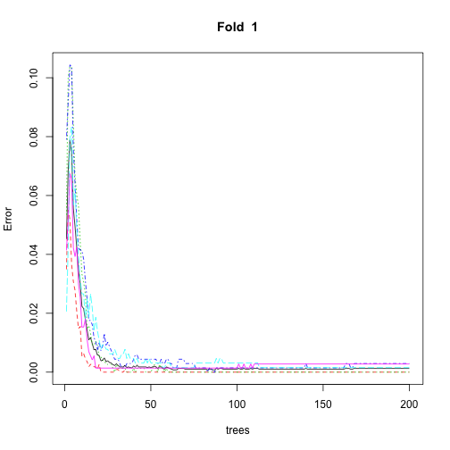

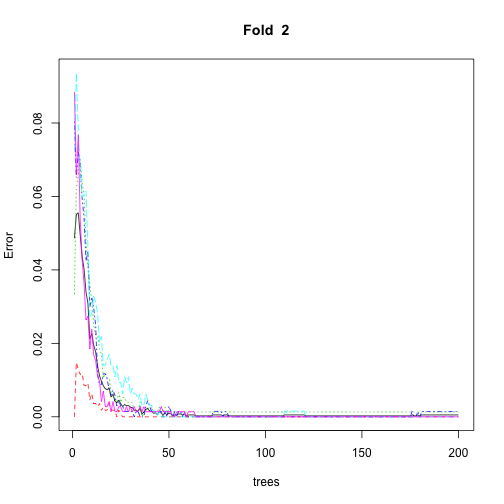

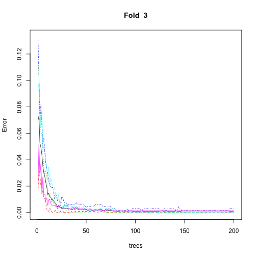

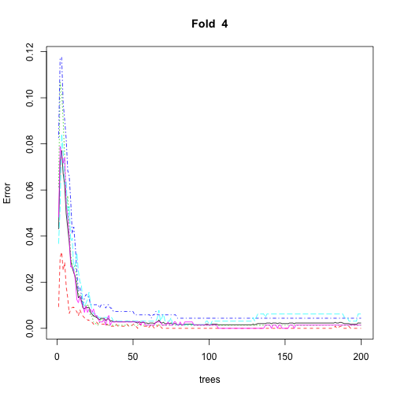

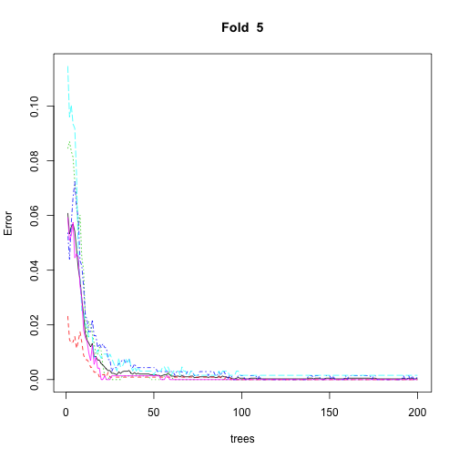

```r
for (i in 1:5) {
    randf <- randomForest(x = train1[(folds == i), -c(60)], y = train1[(folds ==
        i), 60], ntree = 200)
    if (i == 1) {
        foldError <- round(randf$confusion[, 6], digits = 3)
    }
    foldError <- cbind(foldError, round(randf$confusion[, 6], digits = 3))
    plot(randf, main = paste("Fold ", i))
}
```

The plots show that the models converged with (less than) 200 trees. We take a look at the results in terms of class error:

```r
foldError
```

```
##   foldError
## A     0.000 0.000 0.000 0.000 0.000 0.000
## B     0.000 0.000 0.001 0.000 0.001 0.000
## C     0.003 0.003 0.001 0.003 0.004 0.001
## D     0.002 0.002 0.000 0.000 0.006 0.002
## E     0.003 0.003 0.000 0.001 0.001 0.000
```

```r
expError <- round(rowMeans(foldError), digits = 3)
expError
```

```
##     A     B     C     D     E
## 0.000 0.000 0.002 0.002 0.001
```